# Ames housing with tidymodels

2022-12-13

## Ames housing with `tidymodels`

## Loading required packages

```r
library(data.table)
library(tidymodels)
library(AmesHousing)
theme_set(theme_bw())
```

## Loading in initial data

```r
#loading initial data, transforming some features
ames = data.table(ames)
setnames(ames, tolower(names(ames)))
ames[, sale_price := log10(sale_price)]

#convert character columns to factor
charCols = names(Filter(is.character, ames))
ames[, (charCols) := lapply(.SD, as.factor), .SDcols = charCols]
#view data columns and their classes
glimpse(ames)
```

```
## Rows: 2,930
## Columns: 74
## $ ms_subclass        <fct> One_Story_1946_and_Newer_All_Styles, One_Story_1946…
## $ ms_zoning          <fct> Residential_Low_Density, Residential_High_Density, …
## $ lot_frontage       <dbl> 141, 80, 81, 93, 74, 78, 41, 43, 39, 60, 75, 0, 63,…
## $ lot_area           <int> 31770, 11622, 14267, 11160, 13830, 9978, 4920, 5005…
## $ street             <fct> Pave, Pave, Pave, Pave, Pave, Pave, Pave, Pave, Pav…
## $ alley              <fct> No_Alley_Access, No_Alley_Access, No_Alley_Access, …
## $ lot_shape          <fct> Slightly_Irregular, Regular, Slightly_Irregular, Re…
## $ land_contour       <fct> Lvl, Lvl, Lvl, Lvl, Lvl, Lvl, Lvl, HLS, Lvl, Lvl, L…
## $ utilities          <fct> AllPub, AllPub, AllPub, AllPub, AllPub, AllPub, All…
## $ lot_config         <fct> Corner, Inside, Corner, Corner, Inside, Inside, Ins…
## $ land_slope         <fct> Gtl, Gtl, Gtl, Gtl, Gtl, Gtl, Gtl, Gtl, Gtl, Gtl, G…
## $ neighborhood       <fct> North_Ames, North_Ames, North_Ames, North_Ames, Gil…
## $ condition_1        <fct> Norm, Feedr, Norm, Norm, Norm, Norm, Norm, Norm, No…
```

[output cut: 61 more lines]

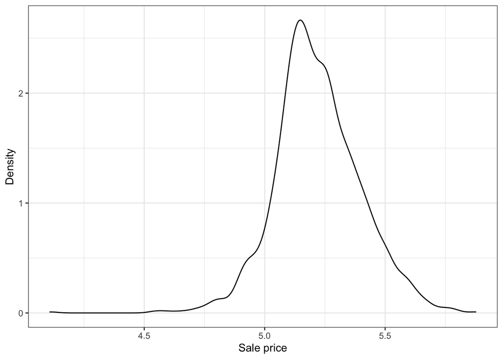

```r
##view distribution of variable of interest
ggplot(ames) +
  geom_density(aes(x = sale_price)) +
  labs(x = 'Sale price', y = 'Density')
```

## Building models with `parsnip`

Specifying and training and initial model on housing data.

```r
#specifying a linear model with the default engine
lmSpec = linear_reg()

#training the model on housing data
lmFit = fit(lmSpec, sale_price ~ latitude + longitude, data = ames)
lmFit
```

```
## parsnip model object
##
##
## Call:
## stats::lm(formula = sale_price ~ latitude + longitude, data = data)
##
## Coefficients:
## (Intercept)     latitude    longitude
##    -308.237        2.839       -2.073
```

We can use `tidy()` to get a standardized model summary table.

```r
data.table(tidy(lmFit))
```

```
##           term    estimate  std.error statistic       p.value
## 1: (Intercept) -308.236774 12.9768256 -23.75286 3.389217e-114
## 2:    latitude    2.838675  0.1617491  17.54986  1.221971e-65
## 3:   longitude   -2.073144  0.1158702 -17.89196  5.033448e-68
```

As with base R, we can make predictions using the trained model.

```r
set.seed(123)

newHomes = data.table(
  latitude = sample(ames$latitude, 5), longitude = sample(ames$longitude, 5))

predict(lmFit, new_data = newHomes)
```

```
## # A tibble: 5 × 1
##   .pred
##   <dbl>
## 1  5.28
## 2  5.35
## 3  5.10
## 4  5.20
## 5  5.18
```

What if we want to use a different model (e.g., a random forest model powered by `ranger`)? We can use `setengine` to specify.

```r
#specifying a regression tree model with rpart as the computational engine
rfSpec = rand_forest()
rfSpec = set_engine(rfSpec, engine = 'ranger') #also could use randomForest
rfSpec = set_mode(rfSpec, mode = 'regression') #since random forest can classify, too

#training the model on housing data
rfFit = fit(rfSpec, sale_price ~ latitude + longitude, data = ames)
rfFit
```

```
## parsnip model object
##
## Ranger result
##
## Call:
##  ranger::ranger(x = maybe_data_frame(x), y = y, num.threads = 1,      verbose = FALSE, seed = sample.int(10^5, 1))
##
## Type:                             Regression
## Number of trees:                  500
## Sample size:                      2930
## Number of independent variables:  2
## Mtry:                             1
## Target node size:                 5
## Variable importance mode:         none
## Splitrule:                        variance
## OOB prediction error (MSE):       0.00904636
## R squared (OOB):                  0.711288
```

```r
data.table(predict(rfFit, new_data = newHomes))
```

```
##       .pred
## 1: 5.410784
## 2: 5.379280
## 3: 5.454406
## 4: 5.276778
## 5: 5.100771
```

## Splitting the data with `rsample`

Typically, you don’t want to train a model on the whole dataset. How can `tidymodels` help? Introducing `rsample`.

```r
set.seed(123)

#split ames data, holding out 25% of data for testing
amesSplit = initial_split(ames, prop = 3/4)

#extracting training split
amesTrain = training(amesSplit)

#extracting testing split
amesTest = testing(amesSplit)
```

## Training and test a model with training and testing data, evaluate rmse

```r
#fitting a model on training daata
rfFit = fit(rfSpec, sale_price ~ longitude + latitude, data = amesTrain)

#making predictions on test data, saving true value
pricePred = data.table(predict(rfFit, new_data = amesTest))
pricePred = cbind(pricePred, sale_price = amesTest$sale_price)

#checking rmse (from yardstick)
rmse(pricePred, truth = sale_price, estimate = .pred)
```

```
## # A tibble: 1 × 3
##   .metric .estimator .estimate
##   <chr>   <chr>          <dbl>
## 1 rmse    standard      0.0887
```

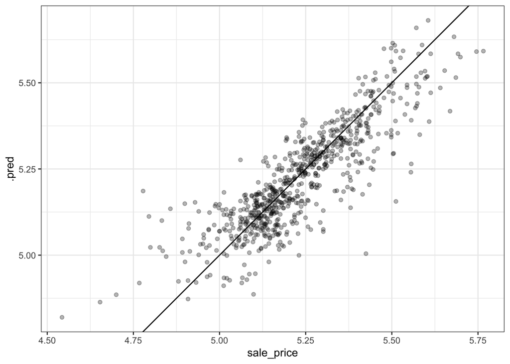

```r
ggplot(pricePred) +
  geom_point(aes(x = sale_price, y = .pred), alpha = 0.3) +
  geom_abline(slope = 1, intercept = 0)
```

## Cross-validation with `rsample`

You can perform more complex sampling schemes than just splitting the data into a training and test set. For example, 10-fold cross-validation with samples stratified by price.

```r
set.seed(123)

cvFolds = vfold_cv(amesTrain, v = 10, strata = sale_price, breaks = 4)
cvFolds
```

```
## #  10-fold cross-validation using stratification
## # A tibble: 10 × 2
##    splits             id
##    <list>             <chr>
##  1 <split [1976/221]> Fold01
##  2 <split [1976/221]> Fold02
##  3 <split [1976/221]> Fold03
##  4 <split [1976/221]> Fold04
##  5 <split [1976/221]> Fold05
##  6 <split [1977/220]> Fold06
##  7 <split [1978/219]> Fold07
##  8 <split [1979/218]> Fold08
##  9 <split [1979/218]> Fold09
## 10 <split [1980/217]> Fold10
```

`rsample` also provides tools for training and testing on resampled data, namely `fit_resamples`.

```r
#train and test model on each fold
fitResamps = fit_resamples(rfSpec, sale_price ~ latitude + longitude, resamples = cvFolds)

#view summary of metrics across folds
metricsSum = collect_metrics(fitResamps)
metricsSum
```

```
## # A tibble: 2 × 6
##   .metric .estimator   mean     n std_err .config
##   <chr>   <chr>       <dbl> <int>   <dbl> <chr>
## 1 rmse    standard   0.0997    10 0.00363 Preprocessor1_Model1
## 2 rsq     standard   0.692     10 0.0143  Preprocessor1_Model1
```

## Using `recipes`

You can use recipes to preprocess the data. First, set up a recipe.

```r
#specify the recipe as a formula
rec = recipe(
  sale_price ~ longitude + latitude + neighborhood + central_air + year_built,
  data = amesTrain)
#set factor levels that occur in less than 5% of data as other
rec = step_other(rec, neighborhood, threshold = 0.05)
#create dumy variables for all factor variables
rec = step_dummy(rec, all_nominal())
#add an interaction term
rec = step_interact(rec, ~ starts_with('central_air'):year_built)
#view recipe and operations
rec
```

```
## Recipe
##
## Inputs:
##
##       role #variables
##    outcome          1
##  predictor          5
##
## Operations:
##
## Collapsing factor levels for neighborhood
## Dummy variables from all_nominal()
## Interactions with starts_with("central_air"):year_built
```

Then, “train” the recipe.

```r
amesRec = prep(rec, amesTrain, verbose = TRUE)
```

```
## oper 1 step other [training]
## oper 2 step dummy [training]
## oper 3 step interact [training]
## The retained training set is ~ 0.22 Mb  in memory.
```

```r
amesRec
```

```
## Recipe
##
## Inputs:
##
##       role #variables
##    outcome          1
##  predictor          5
##
## Training data contained 2197 data points and no missing data.
##
## Operations:
##
## Collapsing factor levels for neighborhood [trained]
## Dummy variables from neighborhood, central_air [trained]
## Interactions with central_air_Y:year_built [trained]
```

Now you can apply it to new data using `bake()`.

```r
amesRecNew = bake(amesRec, amesTest)
data.table(amesRecNew)
```

```
##      longitude latitude year_built sale_price neighborhood_College_Creek
##   1: -93.61939 42.05266       1958   5.235528                          0
##   2: -93.63893 42.06078       1998   5.291147                          0
##   3: -93.63291 42.05917       1985   5.326336                          0
##   4: -93.63637 42.05027       1974   5.230449                          0
##   5: -93.62881 42.05523       1968   5.152288                          0
##  ---
## 729: -93.60819 41.99315       1998   5.186108                          0
## 730: -93.60439 41.99099       1977   5.019116                          0
## 731: -93.60352 41.99216       1972   4.899821                          0
## 732: -93.60044 41.99171       1969   5.146128                          0
## 733: -93.60204 41.99253       1970   4.963788                          0
##      neighborhood_Old_Town neighborhood_Edwards neighborhood_Somerset
##   1:                     0                    0                     0
##   2:                     0                    0                     0
```

[output cut: 33 more lines]

## Tuning models with `tune`

An important part of preparing a machine learning model is tuning the hyperparameters to maximize predictive accuracy (however you might measure it). The `tune` package in `tidymodels` provides utilities to assist in this.

There are several tuning strategies that you can pursue. Below, we’ll demonstrate grid search.

First, specify the hyperparameters that you’re tuning.

```r
ctrl = control_grid(save_pred = TRUE)

#use tune() as a placeholder argument for parameters that you want to tune
rfSpec = rand_forest(mtry = tune())
rfSpec = set_mode(rfSpec, 'regression')
rfSpec = set_engine(rfSpec, 'ranger', regularization.factor = tune())

#show tuning parameters
rfParams = parameters(rfSpec)
rfParams
```

```
## Collection of 2 parameters for tuning
##
##             identifier                  type    object
##                   mtry                  mtry nparam[?]
##  regularization.factor regularization.factor nparam[+]
##
## Model parameters needing finalization:
##    # Randomly Selected Predictors ('mtry')
##
## See `?dials::finalize` or `?dials::update.parameters` for more information.
```

Now, we perform cross validation and grid search.

```r
set.seed(123)

folds = vfold_cv(data = bake(amesRec, new_data = NULL))

rfTune = tune_grid(rfSpec, sale_price ~ ., resamples = folds, grid = 10, control = ctrl)
```

```
## i Creating pre-processing data to finalize unknown parameter: mtry
```

```r
rfTune
```

```
## # Tuning results
## # 10-fold cross-validation
## # A tibble: 10 × 5
##    splits             id     .metrics          .notes           .predictions
##    <list>             <chr>  <list>            <list>           <list>
##  1 <split [1977/220]> Fold01 <tibble [20 × 6]> <tibble [0 × 3]> <tibble>
##  2 <split [1977/220]> Fold02 <tibble [20 × 6]> <tibble [0 × 3]> <tibble>
##  3 <split [1977/220]> Fold03 <tibble [20 × 6]> <tibble [0 × 3]> <tibble>
##  4 <split [1977/220]> Fold04 <tibble [20 × 6]> <tibble [0 × 3]> <tibble>
##  5 <split [1977/220]> Fold05 <tibble [20 × 6]> <tibble [0 × 3]> <tibble>
##  6 <split [1977/220]> Fold06 <tibble [20 × 6]> <tibble [0 × 3]> <tibble>
##  7 <split [1977/220]> Fold07 <tibble [20 × 6]> <tibble [0 × 3]> <tibble>
##  8 <split [1978/219]> Fold08 <tibble [20 × 6]> <tibble [0 × 3]> <tibble>
##  9 <split [1978/219]> Fold09 <tibble [20 × 6]> <tibble [0 × 3]> <tibble>
## 10 <split [1978/219]> Fold10 <tibble [20 × 6]> <tibble [0 × 3]> <tibble>
```

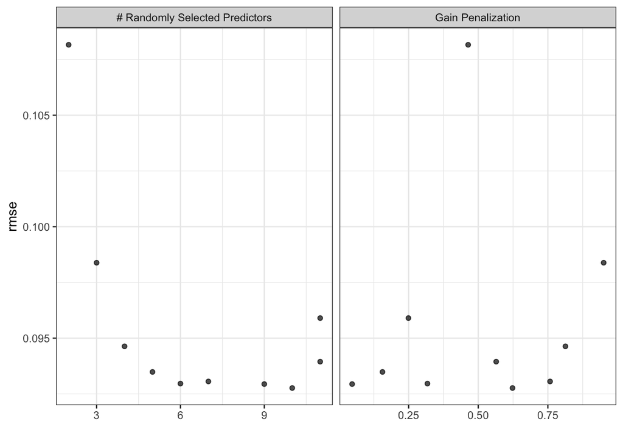

```r
#check results
autoplot(rfTune, metric = 'rmse')
```

Now that we have a table of cv results, we can train the optimal model.

```r
#select the best model by rmse
bestRes = select_best(rfTune, metric = 'rmse')

rfSpecFinal = rand_forest(mtry = bestRes$mtry)
rfSpecFinal = set_mode(rfSpecFinal, 'regression')
rfSpecFinal = set_engine(
  rfSpecFinal, 'ranger', regularization.factor = bestRes$regularization.factor)

#training 'best' model
rfFitFinal = fit(rfSpecFinal, sale_price ~ ., data = bake(amesRec, new_data = NULL))
```

Then, we can apply it to new data (preprocessed based on the recipe from earlier).

```r
predFinal = data.table(predict(rfFitFinal, bake(amesRec, new_data = amesTest)))
predFinal = cbind(predFinal, amesTest)

rmse(predFinal, sale_price, .pred)
```

```
## # A tibble: 1 × 3
##   .metric .estimator .estimate
##   <chr>   <chr>          <dbl>
## 1 rmse    standard      0.0857
```

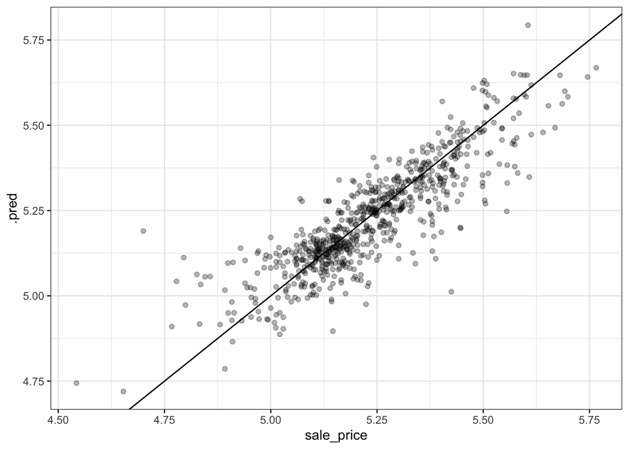

```r
ggplot(predFinal) +
  geom_point(aes(x = sale_price, y = .pred), alpha = 0.3) +
  geom_abline(slope = 1, intercept = 0)
```

## Building `workflows`

We can simplify some of what we did above using workflows. For example, if we want to combine preprocessing and fitting a model, we can do:

```r
amesWf = workflow()
amesWf = add_recipe(amesWf, amesRec)
amesWf = add_model(amesWf, rfSpecFinal)
amesWf = fit(amesWf, data = amesTrain)
#view the workflow
amesWf
```

```
## ══ Workflow [trained] ══════════════════════════════════════════════════════════
## Preprocessor: Recipe
## Model: rand_forest()
##
## ── Preprocessor ────────────────────────────────────────────────────────────────
## 3 Recipe Steps
##
## • step_other()
## • step_dummy()
## • step_interact()
##
## ── Model ───────────────────────────────────────────────────────────────────────
## Ranger result
##
## Call:
##  ranger::ranger(x = maybe_data_frame(x), y = y, mtry = min_cols(~bestRes$mtry,      x), regularization.factor = ~bestRes$regularization.factor,      num.threads = 1, verbose = FALSE, seed = sample.int(10^5,          1))
##
## Type:                             Regression
## Number of trees:                  500
## Sample size:                      2197
## Number of independent variables:  12
## Mtry:                             10
## Target node size:                 5
## Variable importance mode:         none
## Splitrule:                        variance
## OOB prediction error (MSE):       0.008643293
## R squared (OOB):                  0.7303433
```

```r
#use the workflow to predict
predWf = data.table(predict(amesWf, new_data = amesTest))

predWf = cbind(predWf, amesTest)

rmse(predWf, sale_price, .pred)
```

```
## # A tibble: 1 × 3
##   .metric .estimator .estimate
##   <chr>   <chr>          <dbl>
## 1 rmse    standard      0.0855
```

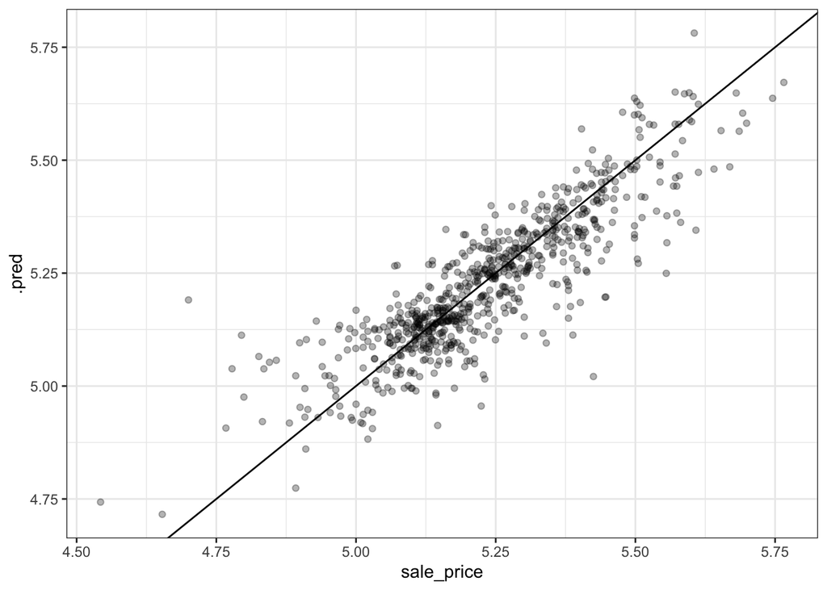

```r
ggplot(predWf) +
  geom_point(aes(x = sale_price, y = .pred), alpha = 0.3) +
  geom_abline(slope = 1, intercept = 0)
```